# SalesPatterns

```python
import pandas as pd
import warnings
warnings.filterwarnings('ignore')
import os
```

```python
#Load Sales data
df = pd.read_csv("C:/Users/User/Documents/Working Directory/MPC FaceForward Sales.csv")

#Define summer fruits
summer = ['APRICOT', 'BLACK PLUM', 'NECTARINE', 'ORG BALCK PLUM', 'ORG NECTARINE', 'ORG PEACH', 'ORG PLUOT', 'ORG RED PLUM',
          'ORG W NECTARINE', 'ORG W PEACH', 'PEACH', 'PLUOT', 'RED PLUM', 'UTL NECTARINES', 'UTL PEACHES', 'UTL PLUMS',
          'UTL PLUOTS', 'W NECTARINE', 'W PEACH']

#Filter summer fruit only
df = df.loc[df['Commodity'].isin(summer)]
```

### Styles each customer bought

```python
# Group by CustomerID and aggregate the unique styles purchased
styles_per_customer = df.groupby('Customer')['Style'].apply(lambda x: list(set(x))).reset_index()

# Styles each customer has bought
styles_per_customer
```

|  | Customer | Style |
| --- | --- | --- |
| 0 | 4-M FRUIT DISTRIBUTORS, INC. | [2LTRCH, SLEGSCH, VF28CH, VF25WD, VF25CH, SLTR... |
| 1 | 99 CENTS ONLY STORES, LLC. | [12/2BAGCH, 10/2 BAG] |
| 2 | A & J PRODUCE CORP. | [2LTRCH, VF25WD, VFEVCH, VFEVWD, SLETRWD] |
| 3 | A & M PRODUCE SALES | [2LTRCH, VF25CH, 2LGS] |
| 4 | A & T TRADING COMPANY LLC | [12/2BAGCH, VFEVCH, 12/2SBAGCH, VF25CH] |
| ... | ... | ... |
| 567 | XPERT LOGISTICS LLC | [VF25CH] |
| 568 | YOSEMITE WHOLESALE CO. | [2LTRCH, 2LGSCH, 2LGS] |
| 569 | YOUNGSTOWN GRAPE DISTRIBUTORS, INC. | [2LERGS29CH, VF25WD, 2LERTR27CH, VF25CH, 2LGS,... |
| 570 | Z & S DISTRIBUTING CO., INC. | [VF25WD, VF25CH, 2LGS, VF24WD, 2LGSCH] |
| 571 | ZAN FRUITS, LLC | [VF25CH] |

572 rows × 2 columns

### Commodities that sold the most

```python
com_counts = df['Commodity'].value_counts().reset_index()
com_counts.columns = ['Commodity', 'Count']

#Display it
com_counts
```

|  | Commodity | Count |
| --- | --- | --- |
| 0 | PEACH | 203506 |
| 1 | NECTARINE | 163031 |
| 2 | W PEACH | 62956 |
| 3 | APRICOT | 14118 |
| 4 | PLUOT | 11113 |
| 5 | ORG PEACH | 11000 |
| 6 | RED PLUM | 4906 |
| 7 | UTL PLUMS | 321 |
| 8 | ORG PLUOT | 62 |
| 9 | UTL PLUOTS | 8 |

### The styles that sold the most

```python
# Number of each style bought
style_counts = df['Style'].value_counts().reset_index()
style_counts.columns = ['Style', 'Count']

# Display it
style_counts.head()
```

|  | Style | Count |
| --- | --- | --- |
| 0 | SLETRCH | 68995 |
| 1 | VF25CH | 50553 |
| 2 | VFEVCH | 39780 |
| 3 | 12/2BAGCH | 27815 |
| 4 | 2LERTR31CH | 23246 |

### Styles that sold the least

```python
style_counts.tail()
```

|  | Style | Count |
| --- | --- | --- |
| 191 | V/F-NU | 2 |
| 192 | 14-2# BAGS | 1 |
| 193 | 2LERNS27LB | 1 |
| 194 | 6/4# CLM | 1 |
| 195 | 2LERNS31# | 1 |

### Commodities Each Country Bought

```python
#Before anything we fix country names and spelling
df['Ship To Country'] = df['Ship To Country'].replace('SOUTH KOREA', 'KOREA')
df['Ship To Country'] = df['Ship To Country'].replace('US', 'USA')
df['Ship To Country'] = df['Ship To Country'].replace('COLUMBIA', 'COLOMBIA')
df['Ship To Country'] = df['Ship To Country'].replace('CAN', 'CANADA')
df['Ship To Country'] = df['Ship To Country'].replace('FIJI ISLAND', 'FIJI ISLAND')
df['Ship To Country'] = df['Ship To Country'].replace('HOUNDURAS', 'HONDURAS')
df['Ship To Country'] = df['Ship To Country'].replace('PHILLIPINES', 'PHILIPPINES')
df['Ship To Country'] = df['Ship To Country'].replace('REP. OF SINGAPORE', 'SINGAPORE')
df['Ship To Country'] = df['Ship To Country'].replace('REPUBLIC SINGAPORE', 'SINGAPORE')
df['Ship To Country'] = df['Ship To Country'].replace('THIALAND', 'THAILAND')


# Group by CustomerID and aggregate the unique styles purchased
#countries = df.groupby('Ship To Country')['Style'].apply(list).reset_index()

countries = df.groupby('Ship To Country')['Commodity'].apply(lambda x: list(set(x))).reset_index()


# Styles each customer has bought
countries
```

|  | Ship To Country | Commodity |
| --- | --- | --- |
| 0 | AUSTRALIA | [PEACH, NECTARINE, W PEACH] |
| 1 | BAHAMAS | [NECTARINE] |
| 2 | BRAZIL | [PEACH, NECTARINE, W PEACH, APRICOT] |
| 3 | CANADA | [PLUOT, RED PLUM, W PEACH, PEACH, UTL PLUMS, O... |
| 4 | CHINA | [PEACH, W PEACH, PLUOT] |
| 5 | COLOMBIA | [PEACH, NECTARINE] |
| 6 | COSTA RICA | [PEACH, NECTARINE] |
| 7 | DOMINICAN REPUBLIC | [PEACH, NECTARINE] |
| 8 | DUBAI | [PEACH, NECTARINE, W PEACH, APRICOT] |
| 9 | ECUADOR | [PEACH, NECTARINE] |
| 10 | EL SALVADOR | [PEACH, NECTARINE, APRICOT] |
| 11 | ENGLAND | [NECTARINE] |
| 12 | EXPORT | [PEACH, NECTARINE, W PEACH] |
| 13 | FIJI ISLAND | [PEACH, NECTARINE] |
| 14 | FRENCH POLYNESIA | [PLUOT, W PEACH, PEACH, NECTARINE, APRICOT] |
| 15 | GUATEMALA | [PEACH, NECTARINE] |
| 16 | HONDURAS | [PEACH, NECTARINE, RED PLUM, PLUOT] |
| 17 | HONG KONG | [RED PLUM, W PEACH, PEACH, NECTARINE, APRICOT] |
| 18 | INDIA | [PLUOT, W PEACH] |
| 19 | INDONESIA | [RED PLUM, W PEACH, PEACH, NECTARINE, APRICOT] |
| 20 | JAPAN | [PEACH, W PEACH] |
| 21 | KUWAIT | [PEACH] |
| 22 | MALAYSIA | [PEACH, NECTARINE, W PEACH, APRICOT] |
| 23 | MEXICO | [PEACH, NECTARINE, APRICOT] |
| 24 | MIDDLE EAST | [PEACH, NECTARINE, W PEACH] |
| 25 | NEW ZEALAND | [PEACH, NECTARINE, W PEACH, PLUOT] |
| 26 | NICARAGUA | [PEACH, NECTARINE] |
| 27 | PANAMA | [PLUOT, NECTARINE, PEACH, RED PLUM] |
| 28 | PHILIPPINES | [PEACH, NECTARINE, W PEACH] |
| 29 | PUERTO RICO | [PEACH, NECTARINE, APRICOT] |
| 30 | QATAR | [RED PLUM, W PEACH] |
| 31 | RUSSIA | [W PEACH] |
| 32 | SAUDI ARABIA | [PLUOT, W PEACH, PEACH, NECTARINE, APRICOT] |
| 33 | SINGAPORE | [PLUOT, W PEACH, PEACH, ORG PEACH, NECTARINE, ... |
| 34 | SOUTH AMERICA | [NECTARINE] |
| 35 | TAIWAN | [PLUOT, W PEACH] |
| 36 | THAILAND | [W PEACH] |
| 37 | UNITED ARAB EMIRATES | [PEACH, NECTARINE, W PEACH, APRICOT] |
| 38 | USA | [PLUOT, RED PLUM, W PEACH, PEACH, UTL PLUMS, O... |
| 39 | VIETNAM | [NECTARINE, W PEACH] |

### Contries That Bought the Most

```python
# Number bought
country_count = df['Ship To Country'].value_counts().reset_index()
country_count.columns = ['Country', 'Count']

# Display the counts
country_count.head()
```

|  | Country | Count |
| --- | --- | --- |
| 0 | USA | 391247 |
| 1 | CANADA | 47183 |
| 2 | MEXICO | 1405 |
| 3 | TAIWAN | 755 |
| 4 | SINGAPORE | 511 |

### Countries that Bought the Least

```python
country_count.tail()
#country_count
```

|  | Country | Count |
| --- | --- | --- |
| 35 | DOMINICAN REPUBLIC | 2 |
| 36 | FIJI ISLAND | 2 |
| 37 | RUSSIA | 2 |
| 38 | ENGLAND | 1 |
| 39 | KUWAIT | 1 |

### Performance by Country

```python
# Summarizing key sales metrics by country
country_metrics = df.groupby('Ship To Country').agg({
    'Sale Price': ['mean', 'sum', 'count'],
    'Profit': ['mean', 'sum'],
    'Qty': ['sum']
}).reset_index()

# Renaming columns for clarity
country_metrics.columns = [
    'Country',
    'Average Sale Price',
    'Total Sales',
    'Number of Transactions',
    'Average Profit',
    'Total Profit',
    'Total Quantity Sold'
]

# Setting display format for floating-point numbers
pd.options.display.float_format = '{:,.2f}'.format

# Redisplaying the dataframe with the new format
country_metrics
```

|  | Country | Average Sale Price | Total Sales | Number of Transactions | Average Profit | Total Profit | Total Quantity Sold |
| --- | --- | --- | --- | --- | --- | --- | --- |
| 0 | AUSTRALIA | 3,573.27 | 214,396.07 | 60 | 0.00 | 0.00 | 4,812.00 |
| 1 | BAHAMAS | 576.00 | 1,728.00 | 3 | 0.00 | 0.00 | 160.00 |
| 2 | BRAZIL | 708.71 | 150,246.93 | 212 | 1.13 | 239.66 | 5,333.00 |
| 3 | CANADA | 1,683.62 | 79,438,232.70 | 47183 | 38.29 | 1,806,545.65 | 3,710,559.00 |
| 4 | CHINA | 551.21 | 3,307.25 | 6 | 0.00 | 0.00 | 231.00 |
| 5 | COLOMBIA | 1,147.40 | 265,049.95 | 231 | -5.54 | -1,278.92 | 22,045.00 |
| 6 | COSTA RICA | 1,751.53 | 404,602.42 | 231 | 0.75 | 173.09 | 24,717.00 |
| 7 | DOMINICAN REPUBLIC | 1,016.00 | 2,032.00 | 2 | 0.00 | 0.00 | 160.00 |
| 8 | DUBAI | 1,061.21 | 211,180.27 | 199 | -16.04 | -3,192.00 | 10,815.00 |
| 9 | ECUADOR | 1,101.40 | 155,296.75 | 141 | -5.26 | -741.76 | 13,840.00 |
| 10 | EL SALVADOR | 1,017.03 | 204,423.00 | 201 | 2.19 | 440.06 | 13,286.00 |
| 11 | ENGLAND | 3,780.00 | 3,780.00 | 1 | 0.00 | 0.00 | 420.00 |
| 12 | EXPORT | 1,477.61 | 63,537.35 | 43 | 0.00 | 0.00 | 4,311.00 |
| 13 | FIJI ISLAND | 558.00 | 1,116.00 | 2 | 126.00 | 252.00 | 80.00 |
| 14 | FRENCH POLYNESIA | 662.45 | 17,223.80 | 26 | 0.00 | 0.00 | 714.00 |
| 15 | GUATEMALA | 1,362.14 | 385,486.30 | 283 | -1.59 | -449.91 | 24,301.00 |
| 16 | HONDURAS | 859.57 | 41,259.40 | 48 | -1.20 | -57.72 | 2,732.00 |
| 17 | HONG KONG | 1,105.69 | 116,097.21 | 105 | 0.36 | 38.18 | 7,528.00 |
| 18 | INDIA | 432.62 | 2,595.75 | 6 | 0.00 | 0.00 | 73.00 |
| 19 | INDONESIA | 417.08 | 41,708.35 | 100 | 2.21 | 221.39 | 1,530.00 |
| 20 | JAPAN | 1,100.06 | 8,800.50 | 8 | 0.00 | 0.00 | 630.00 |
| 21 | KUWAIT | 1,078.65 | 1,078.65 | 1 | 0.00 | 0.00 | 27.00 |
| 22 | MALAYSIA | 624.24 | 26,217.92 | 42 | 2.48 | 104.22 | 1,554.00 |
| 23 | MEXICO | 2,954.14 | 4,150,570.61 | 1405 | -4.88 | -6,850.13 | 252,267.00 |
| 24 | MIDDLE EAST | 641.29 | 10,902.00 | 17 | 0.00 | 0.00 | 600.00 |
| 25 | NEW ZEALAND | 1,474.84 | 302,342.82 | 205 | 93.14 | 19,094.34 | 27,351.00 |
| 26 | NICARAGUA | 778.67 | 4,672.00 | 6 | 0.00 | 0.00 | 320.00 |
| 27 | PANAMA | 1,420.79 | 39,782.00 | 28 | 0.48 | 13.35 | 2,325.00 |
| 28 | PHILIPPINES | 1,041.03 | 9,369.30 | 9 | 161.76 | 1,455.85 | 490.00 |
| 29 | PUERTO RICO | 714.35 | 32,145.85 | 45 | 0.00 | 0.00 | 3,696.00 |
| 30 | QATAR | 189.57 | 1,327.00 | 7 | 0.00 | 0.00 | 60.00 |
| 31 | RUSSIA | 1,667.25 | 3,334.50 | 2 | 0.00 | 0.00 | 95.00 |
| 32 | SAUDI ARABIA | 268.23 | 87,176.25 | 325 | 0.03 | 10.00 | 8,521.00 |
| 33 | SINGAPORE | 1,119.09 | 571,856.10 | 511 | -3.54 | -1,807.80 | 28,504.00 |
| 34 | SOUTH AMERICA | 1,200.00 | 4,800.00 | 4 | 0.00 | 0.00 | 960.00 |
| 35 | TAIWAN | 1,771.40 | 1,337,408.88 | 755 | -23.42 | -17,683.06 | 93,956.00 |
| 36 | THAILAND | 462.40 | 924.80 | 2 | 0.00 | 0.00 | 64.00 |
| 37 | UNITED ARAB EMIRATES | 578.62 | 189,785.80 | 328 | 0.00 | 0.00 | 11,509.00 |
| 38 | USA | 2,176.83 | 851,677,099.35 | 391247 | 76.58 | 29,959,839.98 | 40,320,139.87 |
| 39 | VIETNAM | 798.75 | 3,195.00 | 4 | 0.00 | 0.00 | 194.00 |

### ANOVA Test

```python
from scipy import stats

# Preparing data for ANOVA
data_anova = df[['Ship To Country', 'Sale Price', 'Profit']].dropna()

# Performing ANOVA for Sale Price
anova_sale_price = stats.f_oneway(
    *[group['Sale Price'].values for name, group in data_anova.groupby('Ship To Country')]
)

# Performing ANOVA for Profit
anova_profit = stats.f_oneway(
    *[group['Profit'].values for name, group in data_anova.groupby('Ship To Country')]
)

anova_results = {
    'ANOVA Sale Price': anova_sale_price,
    'ANOVA Profit': anova_profit
}

anova_results
```

```
{'ANOVA Sale Price': F_onewayResult(statistic=31.946454818404398, pvalue=1.19701391580455e-235),
 'ANOVA Profit': F_onewayResult(statistic=2.7522323375887, pvalue=2.6781419964837235e-08)}
```

P-values are much smaller than 0.05, indicating that there are statistically significant differences in the average sale prices across different countries. This means that at least one country's average sale price is significantly different from the others. Both tests show significant differences in sale prices and profits among the countries. **In other words: The country you sell to matters when it comes to profits and sale prices**

# Regression Analysis

```python
import statsmodels.api as sm

# Selecting relevant columns
selected_columns = ['Sale Price', 'Qty', 'Cost', 'FOB Price', 'AP Charges', 'AR Charges',
                    'Grower Charges', 'Profit', 'Order Qty']

# Creating a new dataframe with the selected columns
data_selected = df[selected_columns].dropna()

# Ensuring all data is in numeric format
data_selected = data_selected.apply(pd.to_numeric, errors='coerce').dropna()

# Defining the dependent and independent variables
X = data_selected.drop('Sale Price', axis=1)
y = data_selected['Sale Price']

# Adding a constant to the model (intercept)
X = sm.add_constant(X)

# Building the OLS regression model
ols_model = sm.OLS(y, X).fit()

# Displaying the summary of the model
model_summary = ols_model.summary()
model_summary
```

OLS Regression Results

| Dep. Variable: | Sale Price | R-squared: | 0.988 |
| --- | --- | --- | --- |
| Model: | OLS | Adj. R-squared: | 0.988 |
| Method: | Least Squares | F-statistic: | 6.365e+06 |
| Date: | Wed, 12 Jun 2024 | Prob (F-statistic): | 0.00 |
| Time: | 08:17:18 | Log-Likelihood: | -3.4575e+06 |
| No. Observations: | 469876 | AIC: | 6.915e+06 |
| Df Residuals: | 469869 | BIC: | 6.915e+06 |
| Df Model: | 6 |  |  |
| Covariance Type: | nonrobust |  |  |

|  | coef | std err | t | P>\|t\| | [0.025 | 0.975] |
| --- | --- | --- | --- | --- | --- | --- |
| const | 65.2207 | 0.645 | 101.115 | 0.000 | 63.957 | 66.485 |
| Qty | 0.4129 | 0.006 | 73.134 | 0.000 | 0.402 | 0.424 |
| Cost | 0.4120 | 0.001 | 810.179 | 0.000 | 0.411 | 0.413 |
| FOB Price | 0.6630 | 0.000 | 1467.662 | 0.000 | 0.662 | 0.664 |
| AP Charges | 0.1824 | 0.062 | 2.922 | 0.003 | 0.060 | 0.305 |
| AR Charges | 0.9490 | 0.087 | 10.878 | 0.000 | 0.778 | 1.120 |
| Grower Charges | -8.473e-17 | 1.05e-17 | -8.091 | 0.000 | -1.05e-16 | -6.42e-17 |
| Profit | 0.2510 | 0.001 | 274.538 | 0.000 | 0.249 | 0.253 |
| Order Qty | 0.0131 | 0.000 | 92.349 | 0.000 | 0.013 | 0.013 |

| Omnibus: | 283457.563 | Durbin-Watson: | 1.993 |
| --- | --- | --- | --- |
| Prob(Omnibus): | 0.000 | Jarque-Bera (JB): | 259672700.150 |
| Skew: | 1.473 | Prob(JB): | 0.00 |
| Kurtosis: | 118.129 | Cond. No. | 1.09e+23 |

Notes:  
[1] Standard Errors assume that the covariance matrix of the errors is correctly specified.  
[2] The smallest eigenvalue is 1.41e-33. This might indicate that there are  
strong multicollinearity problems or that the design matrix is singular.

R-Squared is really high which makes sense given the variables we've regressed on. The F-statistic is large, and the p-value is very small (less than 0.05), indicating that the model is statistically significant.

## Market Basket Analysis

This next part I'm still iffy on because interpretability is hard when you have so many combinations. But essentially it uses association rule mining ( Apriori algorithm) to find sets of commodities that frequently co-occur in transactions. It helps in understanding commodity bundling opportunities.

```python
from mlxtend.frequent_patterns import apriori, association_rules

# Assuming the dataset has columns 'transaction_id' and 'item'
# Create a basket matrix
basket = df.groupby(['OrderId', 'Commodity'])['Commodity'].count().unstack().fillna(0)
basket = basket.applymap(lambda x: 1 if x > 0 else 0)

# Apply Apriori algorithm
frequent_itemsets = apriori(basket, min_support=0.01, use_colnames=True)

# Generate association rules
rules = association_rules(frequent_itemsets, metric="lift", min_threshold=1)
rules.head()
```

|  | antecedents | consequents | antecedent support | consequent support | support | confidence | lift | leverage | conviction | zhangs_metric |
| --- | --- | --- | --- | --- | --- | --- | --- | --- | --- | --- |
| 0 | (NECTARINE) | (APRICOT) | 0.51 | 0.06 | 0.03 | 0.07 | 1.04 | 0.00 | 1.00 | 0.08 |
| 1 | (APRICOT) | (NECTARINE) | 0.06 | 0.51 | 0.03 | 0.53 | 1.04 | 0.00 | 1.04 | 0.04 |
| 2 | (W PEACH) | (APRICOT) | 0.30 | 0.06 | 0.02 | 0.07 | 1.17 | 0.00 | 1.01 | 0.20 |
| 3 | (APRICOT) | (W PEACH) | 0.06 | 0.30 | 0.02 | 0.35 | 1.17 | 0.00 | 1.08 | 0.15 |
| 4 | (NECTARINE) | (ORG PEACH) | 0.51 | 0.06 | 0.04 | 0.07 | 1.15 | 0.00 | 1.01 | 0.26 |

```python
rules.tail()
```

|  | antecedents | consequents | antecedent support | consequent support | support | confidence | lift | leverage | conviction | zhangs_metric |
| --- | --- | --- | --- | --- | --- | --- | --- | --- | --- | --- |
| 131 | (RED PLUM, W PEACH) | (PEACH, NECTARINE) | 0.02 | 0.28 | 0.01 | 0.73 | 2.63 | 0.01 | 2.72 | 0.63 |
| 132 | (PEACH) | (RED PLUM, NECTARINE, W PEACH) | 0.56 | 0.01 | 0.01 | 0.02 | 1.54 | 0.00 | 1.01 | 0.81 |
| 133 | (NECTARINE) | (PEACH, W PEACH, RED PLUM) | 0.51 | 0.01 | 0.01 | 0.02 | 1.71 | 0.01 | 1.01 | 0.85 |
| 134 | (W PEACH) | (PEACH, NECTARINE, RED PLUM) | 0.30 | 0.02 | 0.01 | 0.04 | 2.12 | 0.01 | 1.02 | 0.75 |
| 135 | (RED PLUM) | (PEACH, NECTARINE, W PEACH) | 0.03 | 0.11 | 0.01 | 0.36 | 3.35 | 0.01 | 1.39 | 0.73 |

The way you interpret it is by looking at the support and confidence columns. Looking at the first row, confidence column, we can say that 6.55% of the transactions that contain NECTARINE also contain APRICOT and so on.

### Forecast

In this next part we'll focus on WAL-MART STORES, INC. to run our forecast. We'll run Wal-Marts history first

```python
#Import packages
import matplotlib.pyplot as plt
import itertools
import numpy as np
import statsmodels.api as sm
import seaborn as sns
import matplotlib
import pmdarima as pm
import pandas as pd
from datetime import datetime
from pandas.tseries.offsets import MonthEnd
import seaborn as sns
from statsmodels.tsa.statespace.sarimax import SARIMAX
from statsmodels.tsa.seasonal import seasonal_decompose
from statsmodels.tsa.holtwinters import ExponentialSmoothing
```

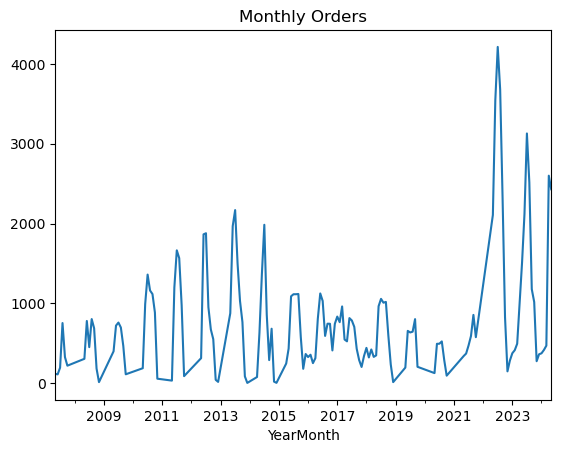

```python
#Reload data
df = pd.read_csv("C:/Users/User/Documents/Working Directory/MPC FaceForward Sales.csv")

# Convert 'Order Date' to datetime
df['Order Date'] = pd.to_datetime(df['Order Date'])

# Filter data for specific customer
df = df[df['Customer'] == 'WAL-MART STORES, INC.']

# Create new variable YearMonth that aggregate data to count orders per month
df['YearMonth'] = df['Order Date'].dt.to_period('M')
monthly_orders = df.groupby('YearMonth').size()

# Convert to time series
ts = monthly_orders.asfreq('M')

# Plot the data to check for stationarity and seasonality visually
ts.plot(title='Monthly Orders')
plt.show()
```

Then we create a pivot table to see how many orderd of each styles they bought every month. For the sake of visualization we will only be looking at observations after 2020.

```python
#Reload data
df = pd.read_csv("C:/Users/User/Documents/Working Directory/MPC FaceForward Sales.csv")

# Convert 'Order Date' to datetime
df['Order Date'] = pd.to_datetime(df['Order Date'])

# Filter out observations before 2020
df = df[df['Order Date'] >= '2020-01-01']

# Filter data for specific customer
df = df[df['Customer'] == 'WAL-MART STORES, INC.']

# Aggregate data to count orders per month
df['Order Date'] = df['Order Date'].dt.to_period('M')

# Group by 'YearMonth' and 'Style' to count the number of each style per month
df1 = df.groupby(['Order Date', 'Style']).size().reset_index(name='Count')

# Pivot the table to get a better view
pivot_table = df1.pivot(index='Order Date', columns='Style', values='Count').fillna(0)
pivot_table
```

| Style Order Date | 10/3 PBAG | 10/4# GRPC | 12/2 G BAG | 12/2# GRPC | 12/2BAGCH | 12/2BAGWD | 12/2GBAGCH | 12/2RPCCH | 12/2SBAGCH | 12/3# CBAG | ... | SLEGSCH | SLEGSWD | VF25CH | VF28CH | VF28WD | W2LERTR27 | W2LERTR29 | W2LERTR31 | W2LERTR33 | WSLERGS |
| --- | --- | --- | --- | --- | --- | --- | --- | --- | --- | --- | --- | --- | --- | --- | --- | --- | --- | --- | --- | --- | --- |
| 2020-05 | 0.00 | 0.00 | 0.00 | 0.00 | 0.00 | 0.00 | 0.00 | 0.00 | 0.00 | 0.00 | ... | 12.00 | 10.00 | 0.00 | 0.00 | 0.00 | 0.00 | 7.00 | 5.00 | 0.00 | 0.00 |
| 2020-06 | 0.00 | 0.00 | 0.00 | 0.00 | 0.00 | 0.00 | 0.00 | 0.00 | 0.00 | 0.00 | ... | 52.00 | 74.00 | 0.00 | 0.00 | 0.00 | 0.00 | 79.00 | 98.00 | 0.00 | 0.00 |
| 2020-07 | 0.00 | 0.00 | 0.00 | 0.00 | 0.00 | 0.00 | 0.00 | 0.00 | 0.00 | 0.00 | ... | 58.00 | 23.00 | 0.00 | 0.00 | 0.00 | 0.00 | 47.00 | 122.00 | 0.00 | 0.00 |
| 2020-08 | 0.00 | 0.00 | 0.00 | 0.00 | 0.00 | 0.00 | 0.00 | 0.00 | 0.00 | 0.00 | ... | 44.00 | 0.00 | 0.00 | 70.00 | 0.00 | 0.00 | 0.00 | 131.00 | 1.00 | 0.00 |
| 2020-09 | 0.00 | 0.00 | 0.00 | 0.00 | 0.00 | 0.00 | 0.00 | 0.00 | 0.00 | 0.00 | ... | 0.00 | 10.00 | 0.00 | 0.00 | 0.00 | 0.00 | 2.00 | 109.00 | 0.00 | 0.00 |
| 2020-10 | 0.00 | 0.00 | 0.00 | 0.00 | 0.00 | 0.00 | 0.00 | 0.00 | 0.00 | 0.00 | ... | 0.00 | 0.00 | 0.00 | 0.00 | 0.00 | 0.00 | 0.00 | 0.00 | 0.00 | 0.00 |
| 2021-05 | 0.00 | 0.00 | 0.00 | 0.00 | 0.00 | 0.00 | 0.00 | 53.00 | 0.00 | 0.00 | ... | 7.00 | 59.00 | 65.00 | 0.00 | 0.00 | 8.00 | 65.00 | 0.00 | 0.00 | 49.00 |
| 2021-06 | 0.00 | 0.00 | 0.00 | 0.00 | 11.00 | 0.00 | 0.00 | 107.00 | 0.00 | 0.00 | ... | 2.00 | 14.00 | 0.00 | 0.00 | 0.00 | 7.00 | 112.00 | 26.00 | 0.00 | 48.00 |
| 2021-07 | 0.00 | 0.00 | 0.00 | 0.00 | 52.00 | 0.00 | 0.00 | 91.00 | 19.00 | 0.00 | ... | 18.00 | 7.00 | 0.00 | 13.00 | 0.00 | 0.00 | 83.00 | 73.00 | 0.00 | 20.00 |
| 2021-08 | 0.00 | 0.00 | 0.00 | 0.00 | 77.00 | 0.00 | 0.00 | 0.00 | 53.00 | 0.00 | ... | 34.00 | 26.00 | 0.00 | 0.00 | 0.00 | 0.00 | 9.00 | 5.00 | 0.00 | 6.00 |
| 2021-09 | 0.00 | 0.00 | 0.00 | 0.00 | 0.00 | 0.00 | 0.00 | 0.00 | 0.00 | 0.00 | ... | 4.00 | 125.00 | 0.00 | 0.00 | 0.00 | 0.00 | 2.00 | 0.00 | 0.00 | 7.00 |
| 2021-10 | 0.00 | 0.00 | 0.00 | 0.00 | 0.00 | 0.00 | 0.00 | 0.00 | 0.00 | 0.00 | ... | 0.00 | 23.00 | 91.00 | 12.00 | 0.00 | 0.00 | 0.00 | 0.00 | 0.00 | 1.00 |
| 2022-05 | 0.00 | 0.00 | 0.00 | 0.00 | 28.00 | 0.00 | 0.00 | 243.00 | 0.00 | 0.00 | ... | 0.00 | 0.00 | 0.00 | 0.00 | 0.00 | 0.00 | 0.00 | 0.00 | 0.00 | 0.00 |
| 2022-06 | 0.00 | 0.00 | 0.00 | 0.00 | 16.00 | 0.00 | 0.00 | 646.00 | 41.00 | 0.00 | ... | 0.00 | 0.00 | 0.00 | 3.00 | 0.00 | 0.00 | 0.00 | 0.00 | 0.00 | 0.00 |
| 2022-07 | 0.00 | 0.00 | 0.00 | 0.00 | 51.00 | 0.00 | 0.00 | 618.00 | 0.00 | 0.00 | ... | 0.00 | 0.00 | 0.00 | 0.00 | 0.00 | 0.00 | 0.00 | 0.00 | 0.00 | 0.00 |
| 2022-08 | 0.00 | 0.00 | 0.00 | 0.00 | 201.00 | 0.00 | 2.00 | 326.00 | 24.00 | 0.00 | ... | 0.00 | 0.00 | 0.00 | 22.00 | 0.00 | 0.00 | 0.00 | 0.00 | 0.00 | 0.00 |
| 2022-09 | 0.00 | 0.00 | 0.00 | 0.00 | 0.00 | 0.00 | 0.00 | 527.00 | 0.00 | 0.00 | ... | 0.00 | 0.00 | 0.00 | 2.00 | 0.00 | 0.00 | 0.00 | 0.00 | 0.00 | 0.00 |
| 2022-10 | 0.00 | 2.00 | 0.00 | 0.00 | 3.00 | 0.00 | 4.00 | 69.00 | 56.00 | 0.00 | ... | 0.00 | 0.00 | 0.00 | 0.00 | 0.00 | 0.00 | 0.00 | 0.00 | 0.00 | 0.00 |
| 2022-11 | 0.00 | 19.00 | 0.00 | 22.00 | 0.00 | 0.00 | 0.00 | 0.00 | 0.00 | 0.00 | ... | 0.00 | 0.00 | 0.00 | 0.00 | 0.00 | 0.00 | 0.00 | 0.00 | 0.00 | 0.00 |
| 2022-12 | 2.00 | 48.00 | 0.00 | 30.00 | 0.00 | 0.00 | 0.00 | 0.00 | 0.00 | 0.00 | ... | 0.00 | 0.00 | 0.00 | 0.00 | 0.00 | 0.00 | 0.00 | 0.00 | 0.00 | 0.00 |
| 2023-01 | 1.00 | 42.00 | 0.00 | 27.00 | 0.00 | 0.00 | 0.00 | 0.00 | 0.00 | 0.00 | ... | 0.00 | 0.00 | 0.00 | 0.00 | 0.00 | 0.00 | 0.00 | 0.00 | 0.00 | 0.00 |
| 2023-02 | 0.00 | 34.00 | 0.00 | 31.00 | 0.00 | 0.00 | 0.00 | 0.00 | 0.00 | 0.00 | ... | 0.00 | 0.00 | 0.00 | 0.00 | 0.00 | 0.00 | 0.00 | 0.00 | 0.00 | 0.00 |
| 2023-03 | 0.00 | 45.00 | 0.00 | 35.00 | 0.00 | 0.00 | 0.00 | 0.00 | 0.00 | 1.00 | ... | 0.00 | 0.00 | 0.00 | 0.00 | 0.00 | 0.00 | 0.00 | 0.00 | 0.00 | 0.00 |
| 2023-04 | 5.00 | 55.00 | 0.00 | 31.00 | 77.00 | 0.00 | 0.00 | 0.00 | 0.00 | 0.00 | ... | 0.00 | 0.00 | 0.00 | 0.00 | 0.00 | 0.00 | 0.00 | 0.00 | 0.00 | 0.00 |
| 2023-05 | 23.00 | 77.00 | 0.00 | 25.00 | 300.00 | 4.00 | 52.00 | 30.00 | 2.00 | 0.00 | ... | 0.00 | 0.00 | 0.00 | 0.00 | 0.00 | 0.00 | 0.00 | 0.00 | 0.00 | 0.00 |
| 2023-06 | 0.00 | 68.00 | 0.00 | 0.00 | 482.00 | 11.00 | 56.00 | 119.00 | 0.00 | 0.00 | ... | 0.00 | 0.00 | 0.00 | 94.00 | 23.00 | 0.00 | 0.00 | 0.00 | 0.00 | 0.00 |
| 2023-07 | 0.00 | 0.00 | 0.00 | 0.00 | 718.00 | 125.00 | 0.00 | 101.00 | 0.00 | 0.00 | ... | 0.00 | 0.00 | 0.00 | 366.00 | 30.00 | 0.00 | 0.00 | 0.00 | 0.00 | 0.00 |
| 2023-08 | 0.00 | 0.00 | 0.00 | 0.00 | 700.00 | 0.00 | 0.00 | 136.00 | 0.00 | 0.00 | ... | 0.00 | 0.00 | 0.00 | 295.00 | 0.00 | 0.00 | 0.00 | 0.00 | 0.00 | 0.00 |
| 2023-09 | 0.00 | 1.00 | 0.00 | 0.00 | 5.00 | 0.00 | 0.00 | 0.00 | 0.00 | 0.00 | ... | 0.00 | 0.00 | 0.00 | 107.00 | 0.00 | 0.00 | 0.00 | 0.00 | 0.00 | 0.00 |
| 2023-10 | 0.00 | 20.00 | 0.00 | 0.00 | 0.00 | 0.00 | 0.00 | 0.00 | 0.00 | 0.00 | ... | 0.00 | 0.00 | 0.00 | 143.00 | 0.00 | 0.00 | 0.00 | 0.00 | 0.00 | 0.00 |
| 2023-11 | 1.00 | 36.00 | 0.00 | 16.00 | 0.00 | 0.00 | 0.00 | 0.00 | 0.00 | 0.00 | ... | 0.00 | 0.00 | 0.00 | 0.00 | 0.00 | 0.00 | 0.00 | 0.00 | 0.00 | 0.00 |
| 2023-12 | 19.00 | 55.00 | 0.00 | 38.00 | 0.00 | 0.00 | 0.00 | 0.00 | 0.00 | 0.00 | ... | 0.00 | 0.00 | 0.00 | 0.00 | 0.00 | 0.00 | 0.00 | 0.00 | 0.00 | 0.00 |
| 2024-01 | 13.00 | 42.00 | 0.00 | 30.00 | 0.00 | 0.00 | 0.00 | 0.00 | 0.00 | 0.00 | ... | 0.00 | 0.00 | 0.00 | 0.00 | 0.00 | 0.00 | 0.00 | 0.00 | 0.00 | 0.00 |
| 2024-02 | 18.00 | 48.00 | 0.00 | 27.00 | 0.00 | 0.00 | 0.00 | 0.00 | 0.00 | 0.00 | ... | 0.00 | 0.00 | 0.00 | 0.00 | 0.00 | 0.00 | 0.00 | 0.00 | 0.00 | 0.00 |
| 2024-03 | 10.00 | 55.00 | 2.00 | 25.00 | 0.00 | 0.00 | 0.00 | 0.00 | 0.00 | 0.00 | ... | 0.00 | 0.00 | 0.00 | 0.00 | 0.00 | 0.00 | 0.00 | 0.00 | 0.00 | 0.00 |
| 2024-04 | 1.00 | 42.00 | 0.00 | 26.00 | 55.00 | 571.00 | 0.00 | 0.00 | 0.00 | 0.00 | ... | 0.00 | 0.00 | 0.00 | 0.00 | 0.00 | 0.00 | 0.00 | 0.00 | 0.00 | 0.00 |
| 2024-05 | 10.00 | 60.00 | 0.00 | 24.00 | 165.00 | 460.00 | 0.00 | 0.00 | 0.00 | 0.00 | ... | 0.00 | 0.00 | 0.00 | 58.00 | 0.00 | 0.00 | 0.00 | 0.00 | 0.00 | 0.00 |

37 rows × 51 columns

```python
# Load data
data = pd.read_csv("C:/Users/andy_/Downloads/MPC FaceForward Sales.csv")

# Convert 'Order Date' to datetime
data['Order Date'] = pd.to_datetime(data['Order Date'])

# Filter data for specific customer
data = data[data['Customer'] == 'WAL-MART STORES, INC.']

# Create new variable Date that aggregates data to count orders per month
data['Date'] = data['Order Date'].dt.to_period('M').dt.to_timestamp()

# Count orders per month
orders = data.groupby('Date').size().reset_index(name='OrderCount')

# Create a complete sequence of months from the start to the end date
complete_months = pd.DataFrame({'Date': pd.date_range(start=orders['Date'].min(), end=orders['Date'].max(), freq='MS')})

# Merge
df = pd.merge(complete_months, orders, on='Date', how='left')

# Replace all NAs with 0
df['OrderCount'].fillna(0, inplace=True)

# Convert to time series object using pandas
ts_df = pd.Series(df['OrderCount'].values, index=df['Date'])
ts_df
```

```
Date
2007-05-01     118.00
2007-06-01     111.00
2007-07-01     195.00
2007-08-01     754.00
2007-09-01     328.00
               ...
2024-02-01     417.00
2024-03-01     471.00
2024-04-01   2,669.00
2024-05-01   2,987.00
2024-06-01      49.00
Length: 206, dtype: float64
```

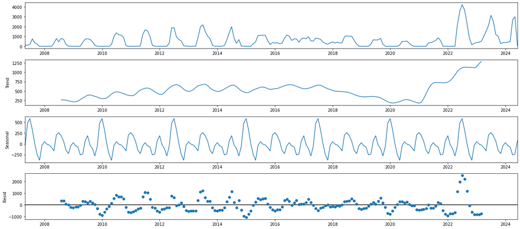

```python
from pylab import rcParams

#drop NAs
#ts_df = ts_month_avg.dropna()

rcParams['figure.figsize'] = 18, 8
decomposition = sm.tsa.seasonal_decompose(ts_df, model='additive', period=30)
fig = decomposition.plot()
plt.show()
```

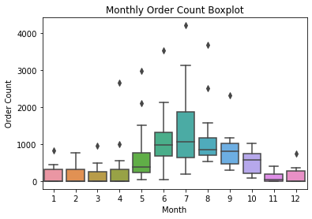

```python
# Boxplot
ts_df_monthly = ts_df.reset_index()
ts_df_monthly['Month'] = ts_df_monthly['Date'].dt.month
sns.boxplot(x='Month', y=ts_df_monthly[0], data=ts_df_monthly)
plt.xlabel('Month')
plt.ylabel("Order Count")
plt.title("Monthly Order Count Boxplot")
plt.show()
```

```python
from pmdarima import auto_arima

# Fit auto_arima model to find the best parameters
auto_model = auto_arima(ts_df, seasonal=True, m=12, trace=True, error_action='ignore', suppress_warnings=True, stepwise=True)
print(auto_model.summary())

# Extract the best parameters
order = auto_model.order
seasonal_order = auto_model.seasonal_order
print(f"Best order: {order}")
print(f"Best seasonal order: {seasonal_order}")

# Fit SARIMA model using the best parameters
model = SARIMAX(ts_df, order= (1,0,1), seasonal_order=(0,1,2,12))
result = model.fit()
print(result.summary())
```

```
Performing stepwise search to minimize aic
 ARIMA(2,1,2)(1,0,1)[12] intercept   : AIC=inf, Time=0.76 sec
 ARIMA(0,1,0)(0,0,0)[12] intercept   : AIC=3133.410, Time=0.03 sec
 ARIMA(1,1,0)(1,0,0)[12] intercept   : AIC=3082.124, Time=0.20 sec
 ARIMA(0,1,1)(0,0,1)[12] intercept   : AIC=3072.673, Time=0.22 sec
 ARIMA(0,1,0)(0,0,0)[12]             : AIC=3131.412, Time=0.03 sec
 ARIMA(0,1,1)(0,0,0)[12] intercept   : AIC=3094.541, Time=0.10 sec
 ARIMA(0,1,1)(1,0,1)[12] intercept   : AIC=3070.760, Time=0.30 sec
 ARIMA(0,1,1)(1,0,0)[12] intercept   : AIC=3069.261, Time=0.28 sec
 ARIMA(0,1,1)(2,0,0)[12] intercept   : AIC=3071.094, Time=0.49 sec
 ARIMA(0,1,1)(2,0,1)[12] intercept   : AIC=3071.902, Time=1.24 sec
 ARIMA(0,1,0)(1,0,0)[12] intercept   : AIC=3086.709, Time=0.17 sec
 ARIMA(1,1,1)(1,0,0)[12] intercept   : AIC=3064.542, Time=0.36 sec
 ARIMA(1,1,1)(0,0,0)[12] intercept   : AIC=3094.809, Time=0.13 sec
 ARIMA(1,1,1)(2,0,0)[12] intercept   : AIC=3066.423, Time=0.87 sec
 ARIMA(1,1,1)(1,0,1)[12] intercept   : AIC=3066.000, Time=0.38 sec
 ARIMA(1,1,1)(0,0,1)[12] intercept   : AIC=3068.453, Time=0.32 sec
 ARIMA(1,1,1)(2,0,1)[12] intercept   : AIC=3066.238, Time=1.34 sec
 ARIMA(2,1,1)(1,0,0)[12] intercept   : AIC=inf, Time=0.63 sec
 ARIMA(1,1,2)(1,0,0)[12] intercept   : AIC=inf, Time=0.71 sec
 ARIMA(0,1,2)(1,0,0)[12] intercept   : AIC=3048.882, Time=0.54 sec
 ARIMA(0,1,2)(0,0,0)[12] intercept   : AIC=3093.925, Time=0.15 sec
 ARIMA(0,1,2)(2,0,0)[12] intercept   : AIC=3050.730, Time=1.20 sec
 ARIMA(0,1,2)(1,0,1)[12] intercept   : AIC=3049.627, Time=0.60 sec
 ARIMA(0,1,2)(0,0,1)[12] intercept   : AIC=3056.268, Time=0.63 sec
 ARIMA(0,1,2)(2,0,1)[12] intercept   : AIC=inf, Time=2.02 sec
 ARIMA(0,1,3)(1,0,0)[12] intercept   : AIC=inf, Time=0.45 sec
 ARIMA(1,1,3)(1,0,0)[12] intercept   : AIC=inf, Time=0.53 sec
 ARIMA(0,1,2)(1,0,0)[12]             : AIC=3047.125, Time=0.35 sec
 ARIMA(0,1,2)(0,0,0)[12]             : AIC=3091.925, Time=0.08 sec
 ARIMA(0,1,2)(2,0,0)[12]             : AIC=3048.905, Time=0.77 sec
 ARIMA(0,1,2)(1,0,1)[12]             : AIC=3047.744, Time=0.31 sec
 ARIMA(0,1,2)(0,0,1)[12]             : AIC=3055.263, Time=0.34 sec
 ARIMA(0,1,2)(2,0,1)[12]             : AIC=inf, Time=1.46 sec
 ARIMA(0,1,1)(1,0,0)[12]             : AIC=3067.321, Time=0.13 sec
 ARIMA(1,1,2)(1,0,0)[12]             : AIC=inf, Time=0.61 sec
 ARIMA(0,1,3)(1,0,0)[12]             : AIC=inf, Time=0.29 sec
 ARIMA(1,1,1)(1,0,0)[12]             : AIC=3062.577, Time=0.28 sec
 ARIMA(1,1,3)(1,0,0)[12]             : AIC=inf, Time=0.69 sec

```

[output cut: 14 more lines]

```
ma.L1         -0.0920      0.026     -3.499      0.000      -0.144      -0.040
ma.L2         -0.7356      0.032    -23.219      0.000      -0.798      -0.673
ar.S.L12       0.5541      0.067      8.279      0.000       0.423       0.685
sigma2      1.565e+05   6422.491     24.375      0.000    1.44e+05    1.69e+05
===================================================================================
Ljung-Box (L1) (Q):                   7.60   Jarque-Bera (JB):              1052.28
Prob(Q):                              0.01   Prob(JB):                         0.00
Heteroskedasticity (H):               4.52   Skew:                             1.66
Prob(H) (two-sided):                  0.00   Kurtosis:                        13.59
===================================================================================

Warnings:
[1] Covariance matrix calculated using the outer product of gradients (complex-step).
Best order: (0, 1, 2)
Best seasonal order: (1, 0, 0, 12)
```

```
                                        SARIMAX Results
===============================================================================================
Dep. Variable:                                       y   No. Observations:                  206
Model:             SARIMAX(1, 0, 1)x(0, 1, [1, 2], 12)   Log Likelihood               -1430.397
Date:                                 Mon, 17 Jun 2024   AIC                           2870.793
Time:                                         10:41:35   BIC                           2887.132
Sample:                                     05-01-2007   HQIC                          2877.409
                                          - 06-01-2024
Covariance Type:                                   opg
==============================================================================
                 coef    std err          z      P>|z|      [0.025      0.975]
------------------------------------------------------------------------------
ar.L1          0.4192      0.037     11.357      0.000       0.347       0.492
ma.L1          0.6585      0.042     15.624      0.000       0.576       0.741
ma.S.L12      -0.4623      0.075     -6.198      0.000      -0.608      -0.316
ma.S.L24      -0.3169      0.148     -2.137      0.033      -0.607      -0.026
sigma2      1.411e+05   7726.900     18.256      0.000    1.26e+05    1.56e+05
===================================================================================
Ljung-Box (L1) (Q):                   0.10   Jarque-Bera (JB):              1164.90
Prob(Q):                              0.75   Prob(JB):                         0.00
Heteroskedasticity (H):               4.19   Skew:                             0.77
Prob(H) (two-sided):                  0.00   Kurtosis:                        14.90
===================================================================================

Warnings:
[1] Covariance matrix calculated using the outer product of gradients (complex-step).
```

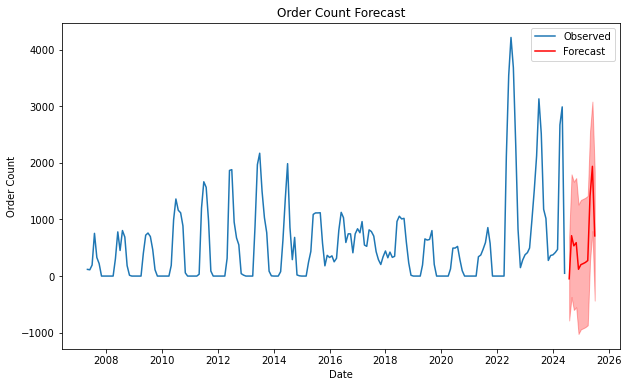

```python
# Forecast for the next n months
forecast_steps = 12
forecast = result.get_forecast(steps=forecast_steps)
forecast_mean = forecast.predicted_mean
forecast_ci = forecast.conf_int()

# Plotting the forecast
plt.figure(figsize=(10, 6))
plt.plot(ts_df, label='Observed')
forecast_index = pd.date_range(start=ts_df.index[-1] + pd.DateOffset(months=1), periods=forecast_steps, freq='M')
plt.plot(forecast_index, forecast.predicted_mean, label='Forecast', color='r')
plt.fill_between(forecast_index, forecast_ci.iloc[:, 0], forecast_ci.iloc[:, 1], color='r', alpha=0.3)
plt.xlabel('Date')
plt.ylabel("Order Count")
plt.title("Order Count Forecast")
plt.legend()
plt.show()
```

```python
# Combine the forecast and confidence intervals into a DataFrame
forecast_index = pd.date_range(start=ts_df.index[-1] + pd.DateOffset(months=1), periods=forecast_steps, freq='M')
forecast_df = pd.DataFrame({
    'Date': forecast_index,
    'Forecast': forecast_mean,
    'Lower CI': forecast_ci.iloc[:, 0],
    'Upper CI': forecast_ci.iloc[:, 1]
})

# Dropping column 'Date' (date is already set as index)
forecast_df = forecast_df.drop(columns=['Date'])

forecast_df
```

|  | Forecast | Lower CI | Upper CI |
| --- | --- | --- | --- |
| 2024-07-01 | -48.16 | -784.52 | 688.20 |
| 2024-08-01 | 713.27 | -369.28 | 1,795.82 |
| 2024-09-01 | 533.73 | -598.76 | 1,666.23 |
| 2024-10-01 | 590.22 | -550.83 | 1,731.26 |
| 2024-11-01 | 120.05 | -1,022.49 | 1,262.59 |
| 2024-12-01 | 201.32 | -941.48 | 1,344.12 |
| 2025-01-01 | 220.96 | -921.89 | 1,363.81 |
| 2025-02-01 | 240.51 | -902.35 | 1,383.37 |
| 2025-03-01 | 273.90 | -868.95 | 1,416.76 |
| 2025-04-01 | 1,415.81 | 273.00 | 2,558.63 |
| 2025-05-01 | 1,937.73 | 794.96 | 3,080.50 |
| 2025-06-01 | 709.29 | -433.47 | 1,852.06 |

The range (confidence interval) within which the true value is likely to fall. For example, on 2024-07-01, the forecasted value is -48.16 with a lower confidence interval of -784.52 and an upper confidence interval of 688.20. This means the actual value on 2024-07-01 is expected to be between -784.52 and 688.20, with a predicted value of -48.16.